# Assignment 6 -- Clustering

**Which method performs best in each dataset?**

With `damping=0.5` AP fails completely. KMeans always does better than that.

1. KMeans; AP calculates too many clusters
2. Both perform equally well
3. Neither: Both fail to recognize the curviness of the data

**Is any dataset not "solved" by the `k`-means or Affinity Propagation? Why? Which parameters could be modified for improvement?**

As already mentioned AP performs very poorly. It predicts too many clusters. We can tweak `damping` and `preference` to remedy that:

```
DATASET 1
```

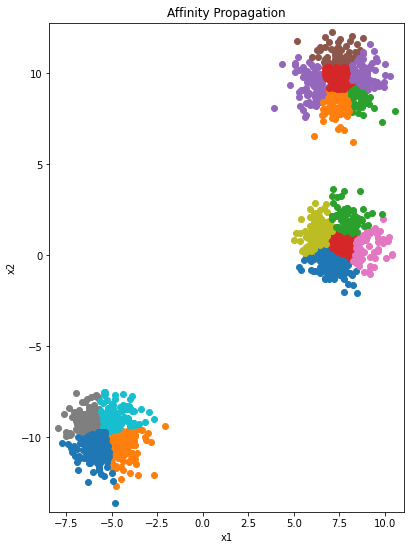

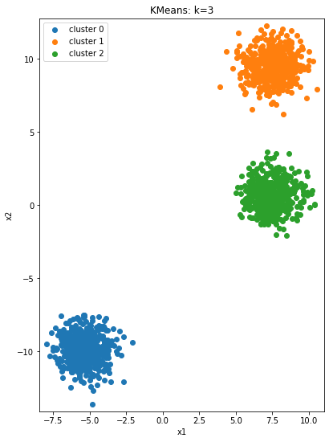

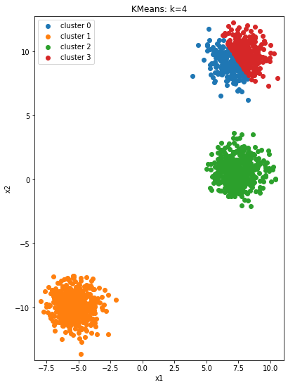

```
DATASET 2
```

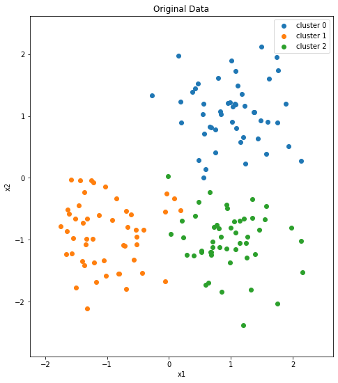

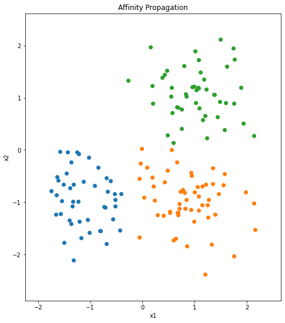

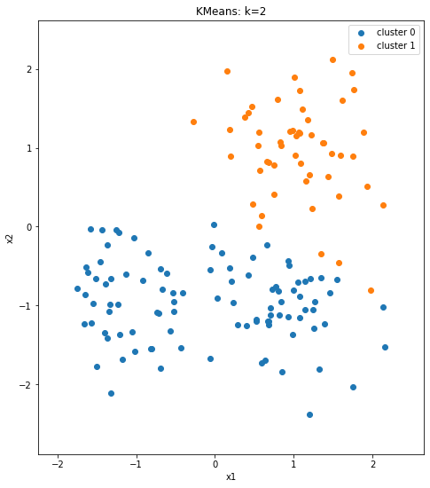

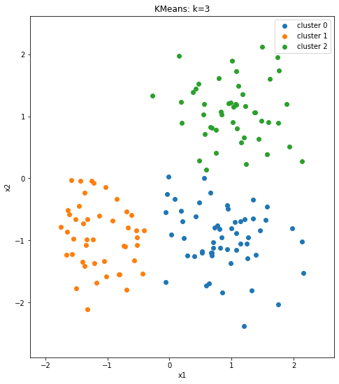

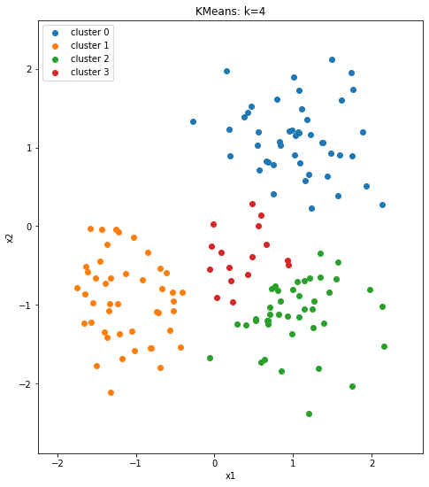

```
DATASET 3
```

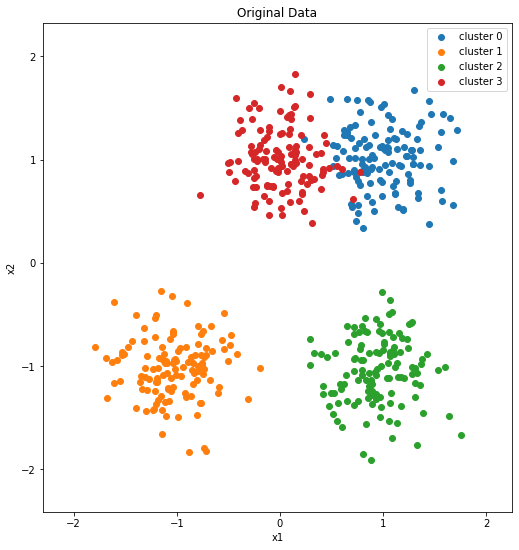

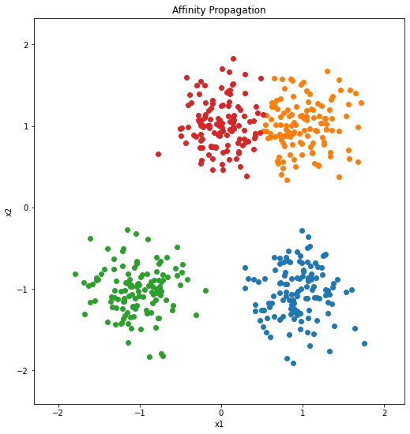

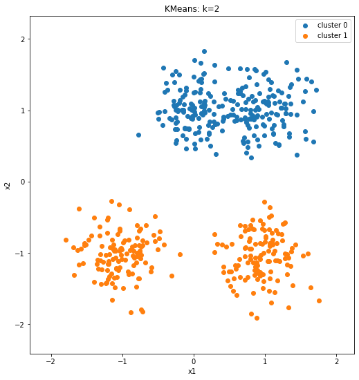

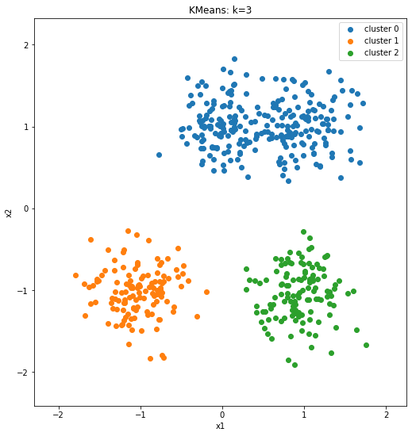

[6 more figures not shown]

```python
a = AffinityPropagation(damping=0.9, preference=-50)
for i, entry in enumerate(data_sets, 1):
    print(f'DATASET {i}')
    compare_ap_km(a, entry[0], entry[1])
```

**Which method is faster?** KMeans is still faster, however, AP now takes less time to compute.

**Which method performs best in each dataset?**

With the improved parameters:

1. KMeans; AP calculates too many clusters
2. AP; KMeans also very well
3. Both equally well
4. Neither: Both fail to recognize the curviness of the data

**Is any dataset not "solved" by the `k`-means or Affinity Propagation? Why? Which parameters could be modified for improvement?**

AP still performs terribly at the first data set: Lower preferences should remedy that:

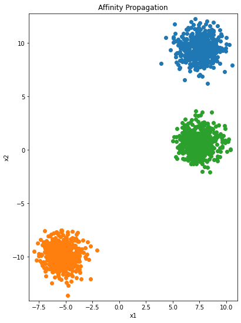

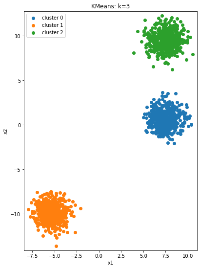

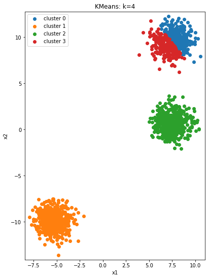

```python
a = AffinityPropagation(damping=0.9, preference=-500)
compare_ap_km(a, data_sets[0][0], data_sets[0][1])
```

In general I would say that KMeans has better "one size fits all" capabilities compared to AP. AP, however, can be more easily tailored to the task at hand.